# Unsupervised Learning: Trade & Ahead

## K-means Clustering

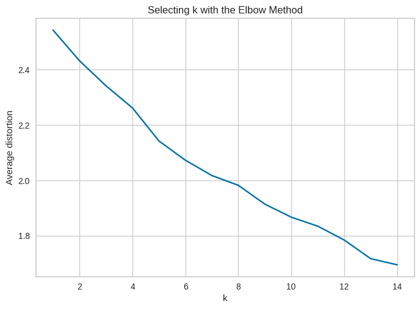

```python
#Finding optimal no. of clusters (1-15)
from scipy.spatial.distance import cdist
clusters=range(1,15)
meanDistortions=[]

for k in clusters:
    model=KMeans(n_clusters=k)
    model.fit(df_Scaled)
    prediction=model.predict(df_Scaled)
    meanDistortions.append(sum(np.min(cdist(df_Scaled, model.cluster_centers_, 'euclidean'), axis=1)) / df_Scaled.shape[0])


plt.plot(clusters, meanDistortions, 'bx-')
plt.xlabel('k')
plt.ylabel('Average distortion')
plt.title('Selecting k with the Elbow Method')
```

Based on the elbow curve, 3-5 clusters may be a suitable number of clusters for the K-Means clustering.

```
For n_clusters = 2, silhouette score is 0.45335782729503565
For n_clusters = 3, silhouette score is 0.40374060030338865
For n_clusters = 4, silhouette score is 0.4246430808437099
For n_clusters = 5, silhouette score is 0.4381539778147092
For n_clusters = 6, silhouette score is 0.40869599703024256
For n_clusters = 7, silhouette score is 0.1207450219233897
For n_clusters = 8, silhouette score is 0.3693991650696542
For n_clusters = 9, silhouette score is 0.35185096182499204
```

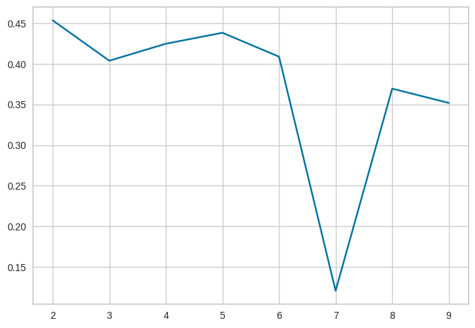

```python
sil_score = []
cluster_list = list(range(2, 10))
for n_clusters in cluster_list:
    clusterer = KMeans(n_clusters=n_clusters, random_state = 1)
    preds = clusterer.fit_predict((df_Scaled))
    # centers = clusterer.cluster_centers_
    score = silhouette_score(df_Scaled, preds)
    sil_score.append(score)
    print("For n_clusters = {}, silhouette score is {}".format(n_clusters, score))

plt.plot(cluster_list, sil_score)
```

Looking at the silhouette scores from 2-9, 3-5 clusters still seems like a good number of clusters.

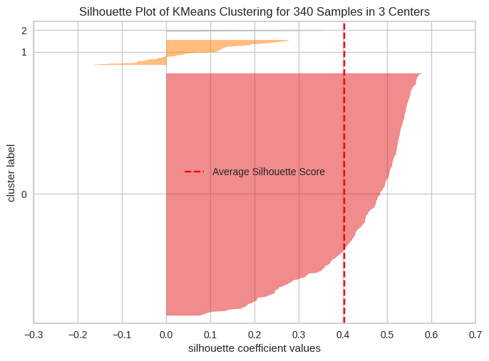

```python
# finding optimal no. of clusters with silhouette coefficients
visualizer = SilhouetteVisualizer(KMeans(3, random_state=1))
visualizer.fit(df_Scaled)
visualizer.show()
```

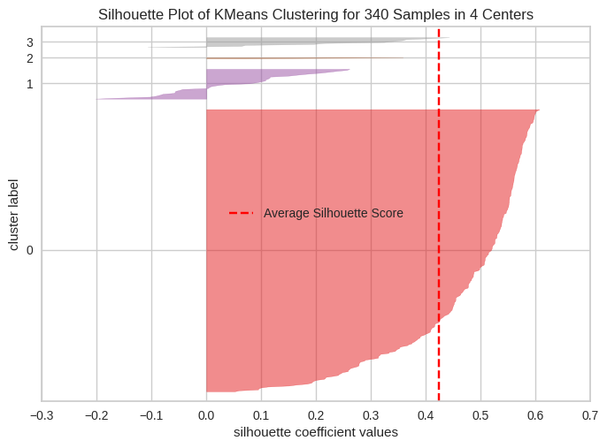

```python
# finding optimal no. of clusters with silhouette coefficients
visualizer = SilhouetteVisualizer(KMeans(4, random_state=1))
visualizer.fit(df_Scaled)
visualizer.show()
```

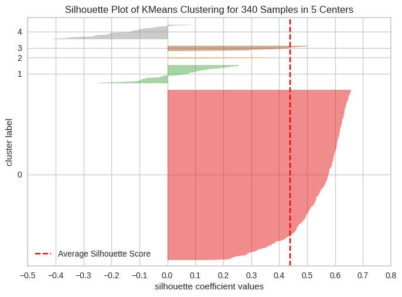

```python
# finding optimal no. of clusters with silhouette coefficients
visualizer = SilhouetteVisualizer(KMeans(5, random_state=1))
visualizer.fit(df_Scaled)
visualizer.show()
```

Lookin at the silhouette plots, 3 and 4 give reasonable clusters, but 5 has many clusters with large negative silhouette scores.

### K-Means 3 Clusters

```python
# Let us first start with K = 3
final_model=KMeans(3, random_state=1)
final_model.fit(df_Scaled)
prediction=final_model.predict(df_Scaled)

#Append the prediction
df["GROUP"] = prediction
df_Scaled["GROUP"] = prediction
print("Groups Assigned : \n")
df.head()
```

```
Groups Assigned :
```

|  | Ticker Symbol | Security | GICS Sector | GICS Sub Industry | Current Price | Price Change | Volatility | ROE | Cash Ratio | Net Cash Flow | Net Income | Earnings Per Share | Estimated Shares Outstanding | P/E Ratio | P/B Ratio | GROUP |
| --- | --- | --- | --- | --- | --- | --- | --- | --- | --- | --- | --- | --- | --- | --- | --- | --- |
| 0 | AAL | American Airlines Group | Industrials | Airlines | 42.349998 | 9.999995 | 1.687151 | 135 | 51 | -604000000 | 7610000000 | 11.39 | 6.681299e+08 | 3.718174 | -8.784219 | 0 |
| 1 | ABBV | AbbVie | Health Care | Pharmaceuticals | 59.240002 | 8.339433 | 2.197887 | 130 | 77 | 51000000 | 5144000000 | 3.15 | 1.633016e+09 | 18.806350 | -8.750068 | 0 |
| 2 | ABT | Abbott Laboratories | Health Care | Health Care Equipment | 44.910000 | 11.301121 | 1.273646 | 21 | 67 | 938000000 | 4423000000 | 2.94 | 1.504422e+09 | 15.275510 | -0.394171 | 0 |
| 3 | ADBE | Adobe Systems Inc | Information Technology | Application Software | 93.940002 | 13.977195 | 1.357679 | 9 | 180 | -240840000 | 629551000 | 1.26 | 4.996437e+08 | 74.555557 | 4.199651 | 0 |
| 4 | ADI | Analog Devices, Inc. | Information Technology | Semiconductors | 55.320000 | -1.827858 | 1.701169 | 14 | 272 | 315120000 | 696878000 | 0.31 | 2.247994e+09 | 178.451613 | 1.059810 | 1 |

```python
#Define dataframe grouped by cluster group number
df_Clust = df.drop(['Ticker Symbol', 'Security', 'GICS Sector', 'GICS Sub Industry'], axis=1).groupby(['GROUP'])
df_Clust = df_Clust.median()
df_Clust
```

| GROUP | Current Price | Price Change | Volatility | ROE | Cash Ratio | Net Cash Flow | Net Income | Earnings Per Share | Estimated Shares Outstanding | P/E Ratio | P/B Ratio |
| --- | --- | --- | --- | --- | --- | --- | --- | --- | --- | --- | --- |
| 0 | 62.055000 | 5.664898 | 1.337858 | 15.0 | 46.5 | 2.819000e+06 | 8.203470e+08 | 3.075 | 2.981832e+08 | 19.442807 | -1.269332 |
| 1 | 32.745001 | -11.770727 | 2.649248 | 13.0 | 53.0 | -1.472000e+07 | -6.210000e+08 | -1.160 | 4.043620e+08 | 93.089287 | 1.600930 |
| 2 | 24.485001 | -13.351992 | 3.482611 | 802.0 | 51.0 | -1.292500e+09 | -1.910650e+10 | -41.815 | 5.195740e+08 | 60.748608 | 1.565141 |

```python
#Check companies in cluster 1
C0_list = df[df['GROUP'] == 0]['Security'].tolist()
C0_list
```

```
['American Airlines Group',
 'AbbVie',
 'Abbott Laboratories',
 'Adobe Systems Inc',
 'Archer-Daniels-Midland Co',
 'Alliance Data Systems',
 'Ameren Corp',
 'American Electric Power',
 'AFLAC Inc',
 'American International Group, Inc.',
 'Apartment Investment & Mgmt',
 'Assurant Inc',
 'Arthur J. Gallagher & Co.',
 'Akamai Technologies Inc',
 'Albemarle Corp',
 'Alaska Air Group Inc',
 'Allstate Corp',
 'Allegion',
 'Applied Materials Inc',
 'AMETEK Inc',
 'Affiliated Managers Group Inc',
 'Amgen Inc',
 'Ameriprise Financial',
 'American Tower Corp A',
 'AutoNation Inc',
 'Anthem Inc.',
 'Aon plc',
 'Amphenol Corp',
 'Arconic Inc',
 'Activision Blizzard',
 'AvalonBay Communities, Inc.',
 'Broadcom',
 'American Water Works Company Inc',
 'American Express Co',
 'Boeing Company',
 'Bank of America Corp',
 'Baxter International Inc.',
 'BB&T Corporation',
 'Bard (C.R.) Inc.',
 'BIOGEN IDEC Inc.',
```

[output cut: 251 more lines]

```
 'Waste Management Inc.',
 'Western Union Co',
 'Weyerhaeuser Corp.',
 'Wyndham Worldwide',
 'Xcel Energy Inc',
 'XL Capital',
 'Exxon Mobil Corp.',
 'Dentsply Sirona',
 'Xerox Corp.',
 'Xylem Inc.',
 'Yahoo Inc.',
 'Yum! Brands Inc',
 'Zimmer Biomet Holdings',
 'Zions Bancorp',
 'Zoetis']
```

```python
#Check number of entires for cluster 1
len(C0_list)
```

```
306
```

```python
#Check companies in cluster 2
C1_list = df[df['GROUP'] == 1]['Security'].tolist()
C1_list
```

```
['Analog Devices, Inc.',
 'Alexion Pharmaceuticals',
 'Amazon.com Inc',
 'Anadarko Petroleum Corp',
 'Baker Hughes Inc',
 'Cabot Oil & Gas',
 'Concho Resources',
 'Devon Energy Corp.',
 'EOG Resources',
 'EQT Corporation',
 'Freeport-McMoran Cp & Gld',
 'Halliburton Co.',
 'Hess Corporation',
 'Hewlett Packard Enterprise',
 'Kinder Morgan',
 'The Mosaic Company',
 'Marathon Oil Corp.',
 'Murphy Oil',
 'Noble Energy Inc',
 'Netflix Inc.',
 'Newfield Exploration Co',
 'National Oilwell Varco Inc.',
 'ONEOK',
 'Occidental Petroleum',
 'Quanta Services Inc.',
 'Range Resources Corp.',
 'Spectra Energy Corp.',
 'Southwestern Energy',
 'Teradata Corp.',
 'Williams Cos.',
 'Wynn Resorts Ltd',
 'Cimarex Energy']
```

```python
#Check number of entires for cluster 1
len(C1_list)
```

```
32
```

```python
#Check companies in cluster 3
C2_list = df[df['GROUP'] == 2]['Security'].tolist()
C2_list
```

```
['Apache Corporation', 'Chesapeake Energy']
```

```python
#Check number of entires for cluster 1
len(C2_list)
```

```
2
```

```
array([[<Axes: title={'center': 'Cash Ratio'}, xlabel='[GROUP]'>,
        <Axes: title={'center': 'Current Price'}, xlabel='[GROUP]'>,
        <Axes: title={'center': 'Earnings Per Share'}, xlabel='[GROUP]'>],
       [<Axes: title={'center': 'Estimated Shares Outstanding'}, xlabel='[GROUP]'>,
        <Axes: title={'center': 'Net Cash Flow'}, xlabel='[GROUP]'>,
        <Axes: title={'center': 'Net Income'}, xlabel='[GROUP]'>],
       [<Axes: title={'center': 'P/B Ratio'}, xlabel='[GROUP]'>,
        <Axes: title={'center': 'P/E Ratio'}, xlabel='[GROUP]'>,
        <Axes: title={'center': 'Price Change'}, xlabel='[GROUP]'>],
       [<Axes: title={'center': 'ROE'}, xlabel='[GROUP]'>,
        <Axes: title={'center': 'Volatility'}, xlabel='[GROUP]'>,
        <Axes: >]], dtype=object)
```

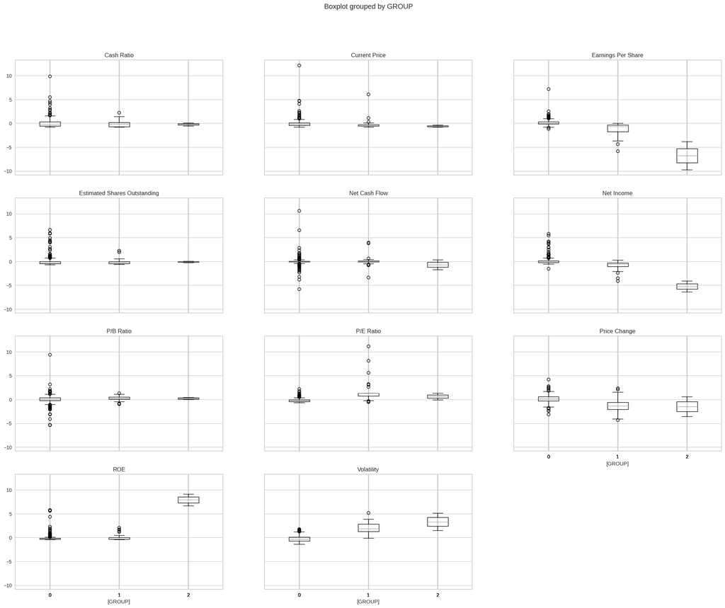

```python
#Graph boxplot of each cluster
df_Scaled.boxplot(by='GROUP', layout = (4,3),figsize=(25,20))
```

```python
# setting the number of components to 2
pca = PCA(n_components=2, random_state=1)

# transforming data and storing results in a dataframe
X_reduced_pca = pca.fit_transform(df_Scaled)
reduced_df_pca = pd.DataFrame(
    data=X_reduced_pca, columns=["Component 1", "Component 2"]
)
```

```python
# checking the amount of variance explained
pca.explained_variance_ratio_.sum()
```

```
np.float64(0.37313915049028845)
```

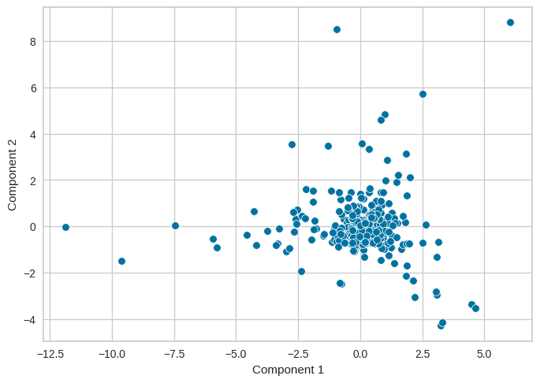

```python
#Plot 2-D post PCA data to visualize clusters
sns.scatterplot(data=reduced_df_pca, x="Component 1", y="Component 2")
```

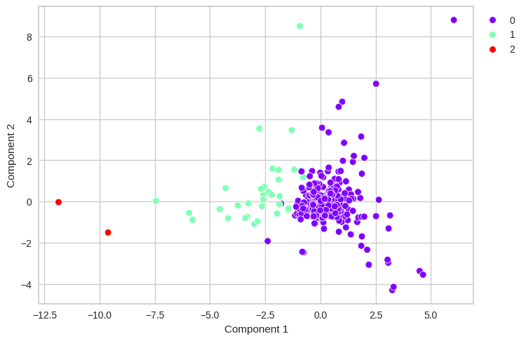

```python
#Plot unique clusters on 2-D PCA scatter plot
sns.scatterplot(
    data=reduced_df_pca,
    x="Component 1",
    y="Component 2",
    hue=df["GROUP"],
    palette="rainbow",
)
plt.legend(bbox_to_anchor=(1, 1))
```

```python
#Highlight maximum median values for each cluster
df_Clust.style.highlight_max(color="lightgreen", axis=0)
```

| GROUP | Current Price | Price Change | Volatility | ROE | Cash Ratio | Net Cash Flow | Net Income | Earnings Per Share | Estimated Shares Outstanding | P/E Ratio | P/B Ratio |
| --- | --- | --- | --- | --- | --- | --- | --- | --- | --- | --- | --- |
| 0 | 62.055000 | 5.664898 | 1.337858 | 15.000000 | 46.500000 | 2819000.000000 | 820347000.000000 | 3.075000 | 298183189.500000 | 19.442807 | -1.269332 |
| 1 | 32.745001 | -11.770727 | 2.649248 | 13.000000 | 53.000000 | -14720000.000000 | -621000000.000000 | -1.160000 | 404361979.450000 | 93.089287 | 1.600930 |
| 2 | 24.485001 | -13.351992 | 3.482611 | 802.000000 | 51.000000 | -1292500000.000000 | -19106500000.000000 | -41.815000 | 519573983.250000 | 60.748608 | 1.565141 |

```python
#Highlight minimum median values for each cluster
df_Clust.style.highlight_min(color="lightblue", axis=0)
```

| GROUP | Current Price | Price Change | Volatility | ROE | Cash Ratio | Net Cash Flow | Net Income | Earnings Per Share | Estimated Shares Outstanding | P/E Ratio | P/B Ratio |
| --- | --- | --- | --- | --- | --- | --- | --- | --- | --- | --- | --- |
| 0 | 62.055000 | 5.664898 | 1.337858 | 15.000000 | 46.500000 | 2819000.000000 | 820347000.000000 | 3.075000 | 298183189.500000 | 19.442807 | -1.269332 |
| 1 | 32.745001 | -11.770727 | 2.649248 | 13.000000 | 53.000000 | -14720000.000000 | -621000000.000000 | -1.160000 | 404361979.450000 | 93.089287 | 1.600930 |
| 2 | 24.485001 | -13.351992 | 3.482611 | 802.000000 | 51.000000 | -1292500000.000000 | -19106500000.000000 | -41.815000 | 519573983.250000 | 60.748608 | 1.565141 |

With 3 Clusters each cluster can be classified as low, medium and high risk companies to invest in (clusters 0, 1, 2 respectively).

This mainly is based on the volatility of each cluster group with the higher volitility equating to higher risk.

**Cluster 0** has highest current price, net cash flow, net income, and earnings per share, but lowest volatility, P/E, P/B and Cash ratios.

Since the companies in this company are healthy in terms of income and earnings per share, investing in these companies long term may be beneficial. Though the initial cost of purchasing the stock will be higher.

**Cluster 1** is middle of the road for all metrics except ROE where it has the minimum values and cash ratio, P/E and P/B where it has the highest value.

With P/E and P/B being high, this can indicate that either the companies are overvalued or are expected to grow. With the highest cash ratio, the companies have enough cash in the short term to pay off liabilities, indicating that the higher P/E and P/B score could be indicative of expected growth. With the volatility being higher this is not a gaurantee, however, and investors should invest with some cation in these stocks. The price to purcahsse these stocks is also lower which means more shares can be purchased with the same amount of money compared to cluster 0 companies.

**Cluster 2** has highest volatility but also the highest ROE by far compared to all other clusters. These stock would be best for short term investments and the market would need to be watched closely to time proper buyiong and selling of shares in these stocks. For long term investments, it is probably best to avoid these companies.

### K-Means 4 Clusters

```python
#Check current df_scaled dataframe
df_Scaled.head()
```

|  | Current Price | Price Change | Volatility | ROE | Cash Ratio | Net Cash Flow | Net Income | Earnings Per Share | Estimated Shares Outstanding | P/E Ratio | P/B Ratio | GROUP |
| --- | --- | --- | --- | --- | --- | --- | --- | --- | --- | --- | --- | --- |
| 0 | -0.393341 | 0.493950 | 0.272749 | 0.989601 | -0.210698 | -0.339355 | 1.554415 | 1.309399 | 0.107863 | -0.652487 | -0.506653 | 0 |
| 1 | -0.220837 | 0.355439 | 1.137045 | 0.937737 | 0.077269 | -0.002335 | 0.927628 | 0.056755 | 1.250274 | -0.311769 | -0.504205 | 0 |
| 2 | -0.367195 | 0.602479 | -0.427007 | -0.192905 | -0.033488 | 0.454058 | 0.744371 | 0.024831 | 1.098021 | -0.391502 | 0.094941 | 0 |
| 3 | 0.133567 | 0.825696 | -0.284802 | -0.317379 | 1.218059 | -0.152497 | -0.219816 | -0.230563 | -0.091622 | 0.947148 | 0.424333 | 0 |
| 4 | -0.260874 | -0.492636 | 0.296470 | -0.265515 | 2.237018 | 0.133564 | -0.202703 | -0.374982 | 1.978399 | 3.293307 | 0.199196 | 1 |

```python
#Drop last test GROUP column for new test
df_Scaled.drop(['GROUP'], axis=1, inplace=True)
df_Scaled.head()
```

|  | Current Price | Price Change | Volatility | ROE | Cash Ratio | Net Cash Flow | Net Income | Earnings Per Share | Estimated Shares Outstanding | P/E Ratio | P/B Ratio |
| --- | --- | --- | --- | --- | --- | --- | --- | --- | --- | --- | --- |
| 0 | -0.393341 | 0.493950 | 0.272749 | 0.989601 | -0.210698 | -0.339355 | 1.554415 | 1.309399 | 0.107863 | -0.652487 | -0.506653 |
| 1 | -0.220837 | 0.355439 | 1.137045 | 0.937737 | 0.077269 | -0.002335 | 0.927628 | 0.056755 | 1.250274 | -0.311769 | -0.504205 |
| 2 | -0.367195 | 0.602479 | -0.427007 | -0.192905 | -0.033488 | 0.454058 | 0.744371 | 0.024831 | 1.098021 | -0.391502 | 0.094941 |
| 3 | 0.133567 | 0.825696 | -0.284802 | -0.317379 | 1.218059 | -0.152497 | -0.219816 | -0.230563 | -0.091622 | 0.947148 | 0.424333 |
| 4 | -0.260874 | -0.492636 | 0.296470 | -0.265515 | 2.237018 | 0.133564 | -0.202703 | -0.374982 | 1.978399 | 3.293307 | 0.199196 |

```python
#Check current columns
df.head()
```

|  | Ticker Symbol | Security | GICS Sector | GICS Sub Industry | Current Price | Price Change | Volatility | ROE | Cash Ratio | Net Cash Flow | Net Income | Earnings Per Share | Estimated Shares Outstanding | P/E Ratio | P/B Ratio | GROUP |
| --- | --- | --- | --- | --- | --- | --- | --- | --- | --- | --- | --- | --- | --- | --- | --- | --- |
| 0 | AAL | American Airlines Group | Industrials | Airlines | 42.349998 | 9.999995 | 1.687151 | 135 | 51 | -604000000 | 7610000000 | 11.39 | 6.681299e+08 | 3.718174 | -8.784219 | 0 |
| 1 | ABBV | AbbVie | Health Care | Pharmaceuticals | 59.240002 | 8.339433 | 2.197887 | 130 | 77 | 51000000 | 5144000000 | 3.15 | 1.633016e+09 | 18.806350 | -8.750068 | 0 |
| 2 | ABT | Abbott Laboratories | Health Care | Health Care Equipment | 44.910000 | 11.301121 | 1.273646 | 21 | 67 | 938000000 | 4423000000 | 2.94 | 1.504422e+09 | 15.275510 | -0.394171 | 0 |
| 3 | ADBE | Adobe Systems Inc | Information Technology | Application Software | 93.940002 | 13.977195 | 1.357679 | 9 | 180 | -240840000 | 629551000 | 1.26 | 4.996437e+08 | 74.555557 | 4.199651 | 0 |
| 4 | ADI | Analog Devices, Inc. | Information Technology | Semiconductors | 55.320000 | -1.827858 | 1.701169 | 14 | 272 | 315120000 | 696878000 | 0.31 | 2.247994e+09 | 178.451613 | 1.059810 | 1 |

```python
#Remove previous GROUP column
df.drop(['GROUP'], axis=1, inplace=True)
df.head()
```

|  | Ticker Symbol | Security | GICS Sector | GICS Sub Industry | Current Price | Price Change | Volatility | ROE | Cash Ratio | Net Cash Flow | Net Income | Earnings Per Share | Estimated Shares Outstanding | P/E Ratio | P/B Ratio |
| --- | --- | --- | --- | --- | --- | --- | --- | --- | --- | --- | --- | --- | --- | --- | --- |
| 0 | AAL | American Airlines Group | Industrials | Airlines | 42.349998 | 9.999995 | 1.687151 | 135 | 51 | -604000000 | 7610000000 | 11.39 | 6.681299e+08 | 3.718174 | -8.784219 |
| 1 | ABBV | AbbVie | Health Care | Pharmaceuticals | 59.240002 | 8.339433 | 2.197887 | 130 | 77 | 51000000 | 5144000000 | 3.15 | 1.633016e+09 | 18.806350 | -8.750068 |
| 2 | ABT | Abbott Laboratories | Health Care | Health Care Equipment | 44.910000 | 11.301121 | 1.273646 | 21 | 67 | 938000000 | 4423000000 | 2.94 | 1.504422e+09 | 15.275510 | -0.394171 |
| 3 | ADBE | Adobe Systems Inc | Information Technology | Application Software | 93.940002 | 13.977195 | 1.357679 | 9 | 180 | -240840000 | 629551000 | 1.26 | 4.996437e+08 | 74.555557 | 4.199651 |
| 4 | ADI | Analog Devices, Inc. | Information Technology | Semiconductors | 55.320000 | -1.827858 | 1.701169 | 14 | 272 | 315120000 | 696878000 | 0.31 | 2.247994e+09 | 178.451613 | 1.059810 |

```python
# Let us first start with K = 4
final_model=KMeans(4, random_state=1)
final_model.fit(df_Scaled)
prediction=final_model.predict(df_Scaled)

#Append the prediction
df["GROUP"] = prediction
df_Scaled["GROUP"] = prediction
print("Groups Assigned : \n")
df.head()
```

```
Groups Assigned :
```

|  | Ticker Symbol | Security | GICS Sector | GICS Sub Industry | Current Price | Price Change | Volatility | ROE | Cash Ratio | Net Cash Flow | Net Income | Earnings Per Share | Estimated Shares Outstanding | P/E Ratio | P/B Ratio | GROUP |
| --- | --- | --- | --- | --- | --- | --- | --- | --- | --- | --- | --- | --- | --- | --- | --- | --- |
| 0 | AAL | American Airlines Group | Industrials | Airlines | 42.349998 | 9.999995 | 1.687151 | 135 | 51 | -604000000 | 7610000000 | 11.39 | 6.681299e+08 | 3.718174 | -8.784219 | 0 |
| 1 | ABBV | AbbVie | Health Care | Pharmaceuticals | 59.240002 | 8.339433 | 2.197887 | 130 | 77 | 51000000 | 5144000000 | 3.15 | 1.633016e+09 | 18.806350 | -8.750068 | 0 |
| 2 | ABT | Abbott Laboratories | Health Care | Health Care Equipment | 44.910000 | 11.301121 | 1.273646 | 21 | 67 | 938000000 | 4423000000 | 2.94 | 1.504422e+09 | 15.275510 | -0.394171 | 0 |
| 3 | ADBE | Adobe Systems Inc | Information Technology | Application Software | 93.940002 | 13.977195 | 1.357679 | 9 | 180 | -240840000 | 629551000 | 1.26 | 4.996437e+08 | 74.555557 | 4.199651 | 0 |
| 4 | ADI | Analog Devices, Inc. | Information Technology | Semiconductors | 55.320000 | -1.827858 | 1.701169 | 14 | 272 | 315120000 | 696878000 | 0.31 | 2.247994e+09 | 178.451613 | 1.059810 | 1 |

```python
#Define dataframe grouped by cluster group number
df_Clust = df.drop(['Ticker Symbol', 'Security', 'GICS Sector', 'GICS Sub Industry'], axis=1).groupby(['GROUP'])
df_Clust = df_Clust.median()
df_Clust
```

| GROUP | Current Price | Price Change | Volatility | ROE | Cash Ratio | Net Cash Flow | Net Income | Earnings Per Share | Estimated Shares Outstanding | P/E Ratio | P/B Ratio |
| --- | --- | --- | --- | --- | --- | --- | --- | --- | --- | --- | --- |
| 0 | 64.480003 | 5.796884 | 1.341731 | 15.0 | 46.0 | 3.390000e+06 | 7.640000e+08 | 3.070 | 2.870130e+08 | 19.564165 | -1.269332 |
| 1 | 32.745001 | -11.770727 | 2.649248 | 13.0 | 53.0 | -1.472000e+07 | -6.210000e+08 | -1.160 | 4.043620e+08 | 93.089287 | 1.600930 |
| 2 | 24.485001 | -13.351992 | 3.482611 | 802.0 | 51.0 | -1.292500e+09 | -1.910650e+10 | -41.815 | 5.195740e+08 | 60.748608 | 1.565141 |
| 3 | 46.220001 | 5.532912 | 1.151454 | 12.0 | 79.0 | -9.110000e+08 | 1.615000e+10 | 3.850 | 4.194805e+09 | 13.004785 | -1.466307 |

```python
#Check companies in cluster 1
C0_list = df[df['GROUP'] == 0]['Security'].tolist()
C0_list
```

```
['American Airlines Group',
 'AbbVie',
 'Abbott Laboratories',
 'Adobe Systems Inc',
 'Archer-Daniels-Midland Co',
 'Alliance Data Systems',
 'Ameren Corp',
 'American Electric Power',
 'AFLAC Inc',
 'American International Group, Inc.',
 'Apartment Investment & Mgmt',
 'Assurant Inc',
 'Arthur J. Gallagher & Co.',
 'Akamai Technologies Inc',
 'Albemarle Corp',
 'Alaska Air Group Inc',
 'Allstate Corp',
 'Allegion',
 'Applied Materials Inc',
 'AMETEK Inc',
 'Affiliated Managers Group Inc',
 'Amgen Inc',
 'Ameriprise Financial',
 'American Tower Corp A',
 'AutoNation Inc',
 'Anthem Inc.',
 'Aon plc',
 'Amphenol Corp',
 'Arconic Inc',
 'Activision Blizzard',
 'AvalonBay Communities, Inc.',
 'Broadcom',
 'American Water Works Company Inc',
 'American Express Co',
 'Boeing Company',
 'Bank of America Corp',
 'Baxter International Inc.',
 'BB&T Corporation',
 'Bard (C.R.) Inc.',
 'BIOGEN IDEC Inc.',
```

[output cut: 240 more lines]

```
 'Whirlpool Corp.',
 'Waste Management Inc.',
 'Western Union Co',
 'Weyerhaeuser Corp.',
 'Wyndham Worldwide',
 'Xcel Energy Inc',
 'XL Capital',
 'Dentsply Sirona',
 'Xerox Corp.',
 'Xylem Inc.',
 'Yahoo Inc.',
 'Yum! Brands Inc',
 'Zimmer Biomet Holdings',
 'Zions Bancorp',
 'Zoetis']
```

```python
#Check number of entires for cluster 1
len(C0_list)
```

```
295
```

```python
#Check companies in cluster 2
C1_list = df[df['GROUP'] == 1]['Security'].tolist()
C1_list
```

```
['Analog Devices, Inc.',
 'Alexion Pharmaceuticals',
 'Amazon.com Inc',
 'Anadarko Petroleum Corp',
 'Baker Hughes Inc',
 'Cabot Oil & Gas',
 'Concho Resources',
 'Devon Energy Corp.',
 'EOG Resources',
 'EQT Corporation',
 'Freeport-McMoran Cp & Gld',
 'Halliburton Co.',
 'Hess Corporation',
 'Hewlett Packard Enterprise',
 'Kinder Morgan',
 'The Mosaic Company',
 'Marathon Oil Corp.',
 'Murphy Oil',
 'Noble Energy Inc',
 'Netflix Inc.',
 'Newfield Exploration Co',
 'National Oilwell Varco Inc.',
 'ONEOK',
 'Occidental Petroleum',
 'Quanta Services Inc.',
 'Range Resources Corp.',
 'Spectra Energy Corp.',
 'Southwestern Energy',
 'Teradata Corp.',
 'Williams Cos.',
 'Wynn Resorts Ltd',
 'Cimarex Energy']
```

```python
#Check number of entires for cluster 1
len(C1_list)
```

```
32
```

```python
#Check companies in cluster 3
C2_list = df[df['GROUP'] == 2]['Security'].tolist()
C2_list
```

```
['Apache Corporation', 'Chesapeake Energy']
```

```python
#Check number of entires for cluster 1
len(C2_list)
```

```
2
```

```python
#Check companies in cluster 4
C3_list = df[df['GROUP'] == 3]['Security'].tolist()
C3_list
```

```
['Citigroup Inc.',
 'Ford Motor',
 'Gilead Sciences',
 'Intel Corp.',
 'JPMorgan Chase & Co.',
 'Coca Cola Company',
 'Pfizer Inc.',
 'AT&T Inc',
 'Verizon Communications',
 'Wells Fargo',
 'Exxon Mobil Corp.']
```

```python
#Check number of entires for cluster 1
len(C3_list)
```

```
11
```

```
array([[<Axes: title={'center': 'Cash Ratio'}, xlabel='[GROUP]'>,
        <Axes: title={'center': 'Current Price'}, xlabel='[GROUP]'>,
        <Axes: title={'center': 'Earnings Per Share'}, xlabel='[GROUP]'>],
       [<Axes: title={'center': 'Estimated Shares Outstanding'}, xlabel='[GROUP]'>,
        <Axes: title={'center': 'Net Cash Flow'}, xlabel='[GROUP]'>,
        <Axes: title={'center': 'Net Income'}, xlabel='[GROUP]'>],
       [<Axes: title={'center': 'P/B Ratio'}, xlabel='[GROUP]'>,
        <Axes: title={'center': 'P/E Ratio'}, xlabel='[GROUP]'>,
        <Axes: title={'center': 'Price Change'}, xlabel='[GROUP]'>],
       [<Axes: title={'center': 'ROE'}, xlabel='[GROUP]'>,
        <Axes: title={'center': 'Volatility'}, xlabel='[GROUP]'>,
        <Axes: >]], dtype=object)
```

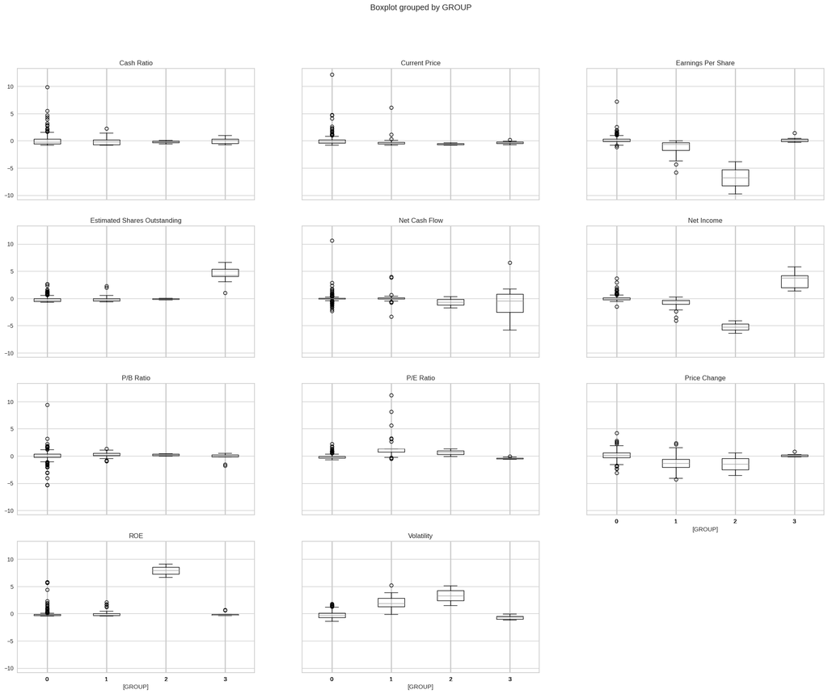

```python
#Graph boxplot of each cluster
df_Scaled.boxplot(by='GROUP', layout = (4,3),figsize=(25,20))
```

```python
# setting the number of components to 2
pca = PCA(n_components=2, random_state=1)

# transforming data and storing results in a dataframe
X_reduced_pca = pca.fit_transform(df_Scaled)
reduced_df_pca = pd.DataFrame(
    data=X_reduced_pca, columns=["Component 1", "Component 2"]
)
```

```python
# checking the amount of variance explained
pca.explained_variance_ratio_.sum()
```

```
np.float64(0.36677827583710565)
```

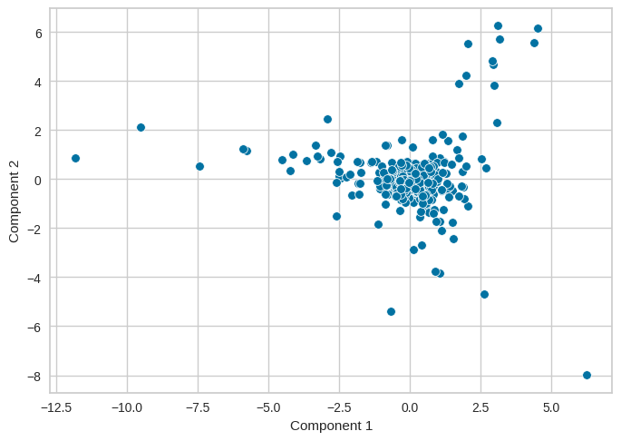

```python
#Plot 2-D post PCA data to visualize clusters
sns.scatterplot(data=reduced_df_pca, x="Component 1", y="Component 2")
```

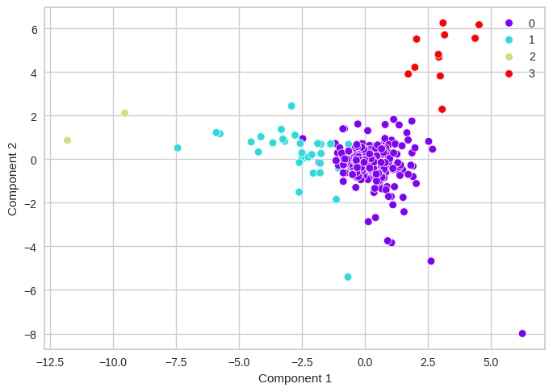

```python
#Plot unique clusters on 2-D PCA scatter plot
sns.scatterplot(
    data=reduced_df_pca,
    x="Component 1",
    y="Component 2",
    hue=df["GROUP"],
    palette="rainbow",
)
plt.legend(bbox_to_anchor=(1, 1))
```

```python
#Highlight maximum median values for each cluster
df_Clust.style.highlight_max(color="lightgreen", axis=0)
```

| GROUP | Current Price | Price Change | Volatility | ROE | Cash Ratio | Net Cash Flow | Net Income | Earnings Per Share | Estimated Shares Outstanding | P/E Ratio | P/B Ratio |
| --- | --- | --- | --- | --- | --- | --- | --- | --- | --- | --- | --- |
| 0 | 64.480003 | 5.796884 | 1.341731 | 15.000000 | 46.000000 | 3390000.000000 | 764000000.000000 | 3.070000 | 287012987.000000 | 19.564165 | -1.269332 |
| 1 | 32.745001 | -11.770727 | 2.649248 | 13.000000 | 53.000000 | -14720000.000000 | -621000000.000000 | -1.160000 | 404361979.450000 | 93.089287 | 1.600930 |
| 2 | 24.485001 | -13.351992 | 3.482611 | 802.000000 | 51.000000 | -1292500000.000000 | -19106500000.000000 | -41.815000 | 519573983.250000 | 60.748608 | 1.565141 |
| 3 | 46.220001 | 5.532912 | 1.151454 | 12.000000 | 79.000000 | -911000000.000000 | 16150000000.000000 | 3.850000 | 4194805195.000000 | 13.004785 | -1.466307 |

```python
#Highlight minimum median values for each cluster
df_Clust.style.highlight_min(color="lightblue", axis=0)
```

| GROUP | Current Price | Price Change | Volatility | ROE | Cash Ratio | Net Cash Flow | Net Income | Earnings Per Share | Estimated Shares Outstanding | P/E Ratio | P/B Ratio |
| --- | --- | --- | --- | --- | --- | --- | --- | --- | --- | --- | --- |
| 0 | 64.480003 | 5.796884 | 1.341731 | 15.000000 | 46.000000 | 3390000.000000 | 764000000.000000 | 3.070000 | 287012987.000000 | 19.564165 | -1.269332 |
| 1 | 32.745001 | -11.770727 | 2.649248 | 13.000000 | 53.000000 | -14720000.000000 | -621000000.000000 | -1.160000 | 404361979.450000 | 93.089287 | 1.600930 |
| 2 | 24.485001 | -13.351992 | 3.482611 | 802.000000 | 51.000000 | -1292500000.000000 | -19106500000.000000 | -41.815000 | 519573983.250000 | 60.748608 | 1.565141 |
| 3 | 46.220001 | 5.532912 | 1.151454 | 12.000000 | 79.000000 | -911000000.000000 | 16150000000.000000 | 3.850000 | 4194805195.000000 | 13.004785 | -1.466307 |

With 4 clusters, the groups can be classified as ver low risk, low risk, medium risk, and high risk cluster.

Looking at 4 clusters, clusters 0 and 3 are the same as cluster 0 in the K-Means with 3 clusters. Looking at the overall metrics of these two clusters, it apperas that their volatility, ROE, earning per share, P/E and P/B are very similar.

They do differentiate in current price with cluster 0 having the most expensive shares of the two and a positive cash flow where cluster 3 is cheaper in terms of current price but has negative cash flow.

Therefore, cluster 0 can be given the "very low risk" classification and cluster three the "low risk" classification. Both are relatively safe stocks to invest in long term, but cluster 0 has a trade off of slightly less earnings per share and higher costs with the health of the companies cash flow being postitve.

Clusters 1 and 2 are equivalent to the clusters 1 and 2 of the K-Means 3 test. Therefore, cluster 1 maintains its "medium risk" status and cluster 2 its "high risk status.

## Hierarchical Clustering

```python
#Check current df_Scaled columns
df_Scaled.head()
```

|  | Current Price | Price Change | Volatility | ROE | Cash Ratio | Net Cash Flow | Net Income | Earnings Per Share | Estimated Shares Outstanding | P/E Ratio | P/B Ratio | GROUP |
| --- | --- | --- | --- | --- | --- | --- | --- | --- | --- | --- | --- | --- |
| 0 | -0.393341 | 0.493950 | 0.272749 | 0.989601 | -0.210698 | -0.339355 | 1.554415 | 1.309399 | 0.107863 | -0.652487 | -0.506653 | 0 |
| 1 | -0.220837 | 0.355439 | 1.137045 | 0.937737 | 0.077269 | -0.002335 | 0.927628 | 0.056755 | 1.250274 | -0.311769 | -0.504205 | 0 |
| 2 | -0.367195 | 0.602479 | -0.427007 | -0.192905 | -0.033488 | 0.454058 | 0.744371 | 0.024831 | 1.098021 | -0.391502 | 0.094941 | 0 |
| 3 | 0.133567 | 0.825696 | -0.284802 | -0.317379 | 1.218059 | -0.152497 | -0.219816 | -0.230563 | -0.091622 | 0.947148 | 0.424333 | 0 |
| 4 | -0.260874 | -0.492636 | 0.296470 | -0.265515 | 2.237018 | 0.133564 | -0.202703 | -0.374982 | 1.978399 | 3.293307 | 0.199196 | 1 |

```python
#Create copy of df_Scaled without the K-Means GROUP column
df_Scaled2 = df_Scaled.drop(['GROUP'], axis=1)
df_Scaled2.head()
```

|  | Current Price | Price Change | Volatility | ROE | Cash Ratio | Net Cash Flow | Net Income | Earnings Per Share | Estimated Shares Outstanding | P/E Ratio | P/B Ratio |
| --- | --- | --- | --- | --- | --- | --- | --- | --- | --- | --- | --- |
| 0 | -0.393341 | 0.493950 | 0.272749 | 0.989601 | -0.210698 | -0.339355 | 1.554415 | 1.309399 | 0.107863 | -0.652487 | -0.506653 |
| 1 | -0.220837 | 0.355439 | 1.137045 | 0.937737 | 0.077269 | -0.002335 | 0.927628 | 0.056755 | 1.250274 | -0.311769 | -0.504205 |
| 2 | -0.367195 | 0.602479 | -0.427007 | -0.192905 | -0.033488 | 0.454058 | 0.744371 | 0.024831 | 1.098021 | -0.391502 | 0.094941 |
| 3 | 0.133567 | 0.825696 | -0.284802 | -0.317379 | 1.218059 | -0.152497 | -0.219816 | -0.230563 | -0.091622 | 0.947148 | 0.424333 |
| 4 | -0.260874 | -0.492636 | 0.296470 | -0.265515 | 2.237018 | 0.133564 | -0.202703 | -0.374982 | 1.978399 | 3.293307 | 0.199196 |

```python
# list of distance metrics
distance_metrics = ["euclidean", "chebyshev", "mahalanobis", "cityblock"]

# list of linkage methods
linkage_methods = ["single", "complete", "average", "weighted"]

high_cophenet_corr = 0
high_dm_lm = [0, 0]

for dm in distance_metrics:
    for lm in linkage_methods:
        Z = linkage(df_Scaled2, metric=dm, method=lm)
        c, coph_dists = cophenet(Z, pdist(df_Scaled2))
        print(
            "Cophenetic correlation for {} distance and {} linkage is {}.".format(
                dm.capitalize(), lm, c
            )
        )
        if high_cophenet_corr < c:
            high_cophenet_corr = c
            high_dm_lm[0] = dm
            high_dm_lm[1] = lm
```

```
Cophenetic correlation for Euclidean distance and single linkage is 0.9232271494002922.
Cophenetic correlation for Euclidean distance and complete linkage is 0.7873280186580672.
Cophenetic correlation for Euclidean distance and average linkage is 0.9422540609560814.
Cophenetic correlation for Euclidean distance and weighted linkage is 0.8693784298129404.
Cophenetic correlation for Chebyshev distance and single linkage is 0.9062538164750717.
Cophenetic correlation for Chebyshev distance and complete linkage is 0.598891419111242.
Cophenetic correlation for Chebyshev distance and average linkage is 0.9338265528030499.
Cophenetic correlation for Chebyshev distance and weighted linkage is 0.9127355892367.
Cophenetic correlation for Mahalanobis distance and single linkage is 0.925919553052459.
Cophenetic correlation for Mahalanobis distance and complete linkage is 0.7925307202850002.
Cophenetic correlation for Mahalanobis distance and average linkage is 0.9247324030159736.
Cophenetic correlation for Mahalanobis distance and weighted linkage is 0.8708317490180428.
Cophenetic correlation for Cityblock distance and single linkage is 0.9334186366528574.
Cophenetic correlation for Cityblock distance and complete linkage is 0.7375328863205818.
Cophenetic correlation for Cityblock distance and average linkage is 0.9302145048594667.
Cophenetic correlation for Cityblock distance and weighted linkage is 0.731045513520281.
```

Based on the copheneitc scores, the average linkage for all distances performs well.

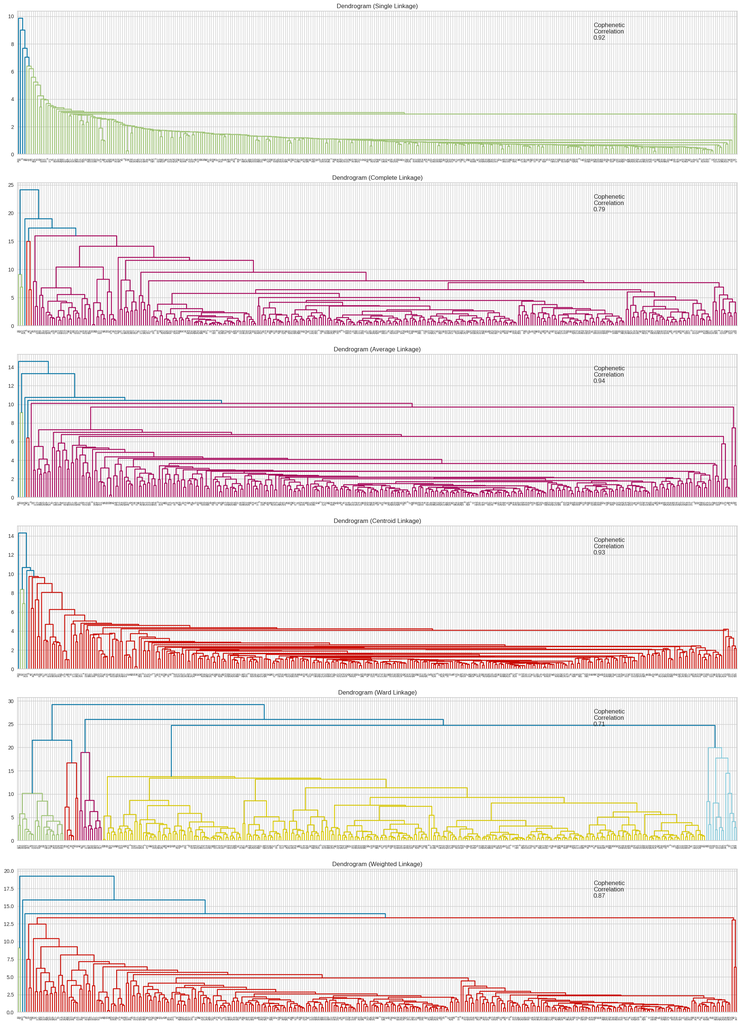

```python
# list of linkage methods
linkage_methods = ["single", "complete", "average", "centroid", "ward", "weighted"]

# lists to save results of cophenetic correlation calculation
compare_cols = ["Linkage", "Cophenetic Coefficient"]

# to create a subplot image
fig, axs = plt.subplots(len(linkage_methods), 1, figsize=(25, 35))

# We will enumerate through the list of linkage methods above
# For each linkage method, we will plot the dendrogram and calculate the cophenetic correlation
for i, method in enumerate(linkage_methods):
    Z = linkage(df_Scaled2, metric="euclidean", method=method)

    dendrogram(Z, ax=axs[i])
    axs[i].set_title(f"Dendrogram ({method.capitalize()} Linkage)")

    coph_corr, coph_dist = cophenet(Z, pdist(df_Scaled2))
    axs[i].annotate(
        f"Cophenetic\nCorrelation\n{coph_corr:0.2f}",
        (0.80, 0.80),
        xycoords="axes fraction",
    )
```

Looking at diffent linkages with the euclidean distance, average gives the best cophenetic score but with a few very small clusters and one massive cluster.

Ward linkage has a lower cophenetic score but does provide better clustering of the different companies.

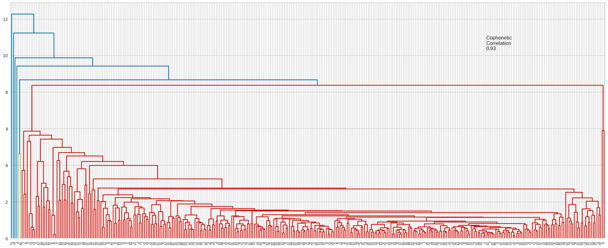

```python
#Check average linkage with chebyshev distance
fig, axs = plt.subplots(1, 1, figsize=(25, 10))
Z = linkage(df_Scaled2, metric="chebyshev", method='average')
dendrogram(Z,ax=axs)
coph_corr, coph_dist = cophenet(Z, pdist(df_Scaled2))
axs.annotate(
        f"Cophenetic\nCorrelation\n{coph_corr:0.2f}",
        (0.80, 0.80),
        xycoords="axes fraction",
    )
```

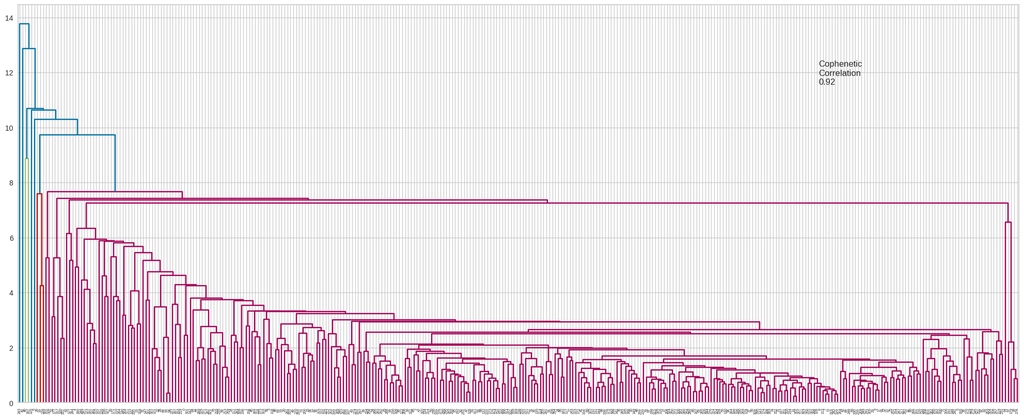

```python
#Check average linkage with mahalanobis distance
fig, axs = plt.subplots(1, 1, figsize=(25, 10))
Z = linkage(df_Scaled2, metric="mahalanobis", method='average')
dendrogram(Z,ax=axs)
coph_corr, coph_dist = cophenet(Z, pdist(df_Scaled2))
axs.annotate(
        f"Cophenetic\nCorrelation\n{coph_corr:0.2f}",
        (0.80, 0.80),
        xycoords="axes fraction",
    )
```

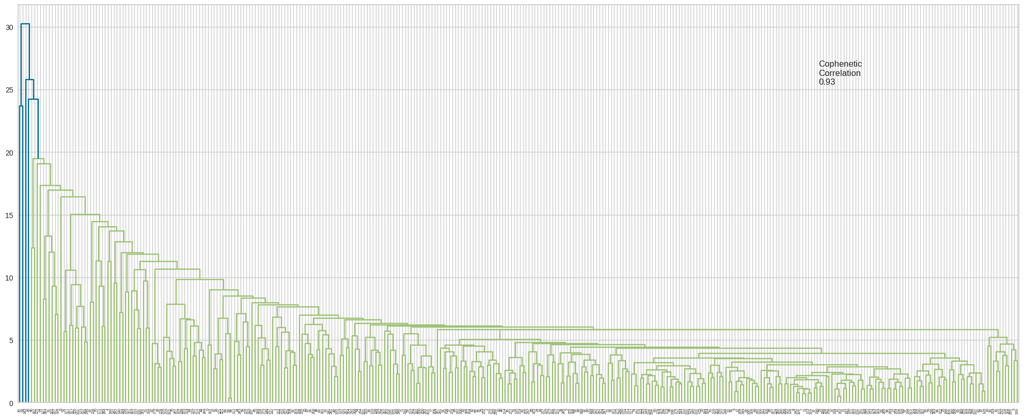

```python
#Check average linkage with cityblock distance
fig, axs = plt.subplots(1, 1, figsize=(25, 10))
Z = linkage(df_Scaled2, metric="cityblock", method='average')
dendrogram(Z,ax=axs)
coph_corr, coph_dist = cophenet(Z, pdist(df_Scaled2))
axs.annotate(
        f"Cophenetic\nCorrelation\n{coph_corr:0.2f}",
        (0.80, 0.80),
        xycoords="axes fraction",
    )
```

The result is similar to the euclidean distance and average linkage in that there are many small clusters with one massive cluster.

### Ward (Best distinct cluster groups)

```python
#Create model using euclidean distance and ward linkage
HCmodel = AgglomerativeClustering(n_clusters=5, metric="euclidean", linkage="ward")
HCmodel.fit(df_Scaled2)
```

```
AgglomerativeClustering(n_clusters=5)
```

```python
#Create dataframe copy for this test
df_2 = df.drop('GROUP', axis=1)
df_2.head()
```

|  | Ticker Symbol | Security | GICS Sector | GICS Sub Industry | Current Price | Price Change | Volatility | ROE | Cash Ratio | Net Cash Flow | Net Income | Earnings Per Share | Estimated Shares Outstanding | P/E Ratio | P/B Ratio |
| --- | --- | --- | --- | --- | --- | --- | --- | --- | --- | --- | --- | --- | --- | --- | --- |
| 0 | AAL | American Airlines Group | Industrials | Airlines | 42.349998 | 9.999995 | 1.687151 | 135 | 51 | -604000000 | 7610000000 | 11.39 | 6.681299e+08 | 3.718174 | -8.784219 |
| 1 | ABBV | AbbVie | Health Care | Pharmaceuticals | 59.240002 | 8.339433 | 2.197887 | 130 | 77 | 51000000 | 5144000000 | 3.15 | 1.633016e+09 | 18.806350 | -8.750068 |
| 2 | ABT | Abbott Laboratories | Health Care | Health Care Equipment | 44.910000 | 11.301121 | 1.273646 | 21 | 67 | 938000000 | 4423000000 | 2.94 | 1.504422e+09 | 15.275510 | -0.394171 |
| 3 | ADBE | Adobe Systems Inc | Information Technology | Application Software | 93.940002 | 13.977195 | 1.357679 | 9 | 180 | -240840000 | 629551000 | 1.26 | 4.996437e+08 | 74.555557 | 4.199651 |
| 4 | ADI | Analog Devices, Inc. | Information Technology | Semiconductors | 55.320000 | -1.827858 | 1.701169 | 14 | 272 | 315120000 | 696878000 | 0.31 | 2.247994e+09 | 178.451613 | 1.059810 |

```python
#Place cluster label in new dataframe
df_Scaled2["HC_Clusters"] = HCmodel.labels_
df_2["HC_Clusters"] = HCmodel.labels_
```

```python
#Calculate mean of values for each group
cluster_profile = df_2.groupby("HC_Clusters").mean(numeric_only=True)
```

```python
#Group by Cluster and GICS sector
cluster_profile["count_in_each_segments"] = (
    df_2.groupby("HC_Clusters")["GICS Sector"].count().values
)
```

```python
# let's see the names of the companies in each cluster
for cl in df_2["HC_Clusters"].unique():
    print("In cluster {}, the following companies are present:".format(cl))
    print(df_2[df_2["HC_Clusters"] == cl]["Security"].unique())
    print()
```

```
In cluster 3, the following companies are present:
['American Airlines Group' 'AbbVie' 'Abbott Laboratories'
 'Adobe Systems Inc' 'Analog Devices, Inc.' 'Archer-Daniels-Midland Co'
 'Ameren Corp' 'American Electric Power' 'AFLAC Inc'
 'American International Group, Inc.' 'Apartment Investment & Mgmt'
 'Assurant Inc' 'Arthur J. Gallagher & Co.' 'Akamai Technologies Inc'
 'Albemarle Corp' 'Alaska Air Group Inc' 'Allstate Corp'
 'Applied Materials Inc' 'AMETEK Inc' 'Affiliated Managers Group Inc'
 'Ameriprise Financial' 'American Tower Corp A' 'AutoNation Inc'
 'Anthem Inc.' 'Aon plc' 'Amphenol Corp' 'Arconic Inc'
 'Activision Blizzard' 'AvalonBay Communities, Inc.' 'Broadcom'
 'American Water Works Company Inc' 'American Express Co' 'Boeing Company'
 'Baxter International Inc.' 'BB&T Corporation' 'Bard (C.R.) Inc.'
 'BIOGEN IDEC Inc.' 'The Bank of New York Mellon Corp.' 'Ball Corp'
 'Bristol-Myers Squibb' 'Boston Scientific' 'BorgWarner'
 'Boston Properties' 'Caterpillar Inc.' 'Chubb Limited' 'CBRE Group'
 'Crown Castle International Corp.' 'Carnival Corp.' 'Celgene Corp.'
 'CF Industries Holdings Inc' 'Citizens Financial Group' 'Church & Dwight'
 'C. H. Robinson Worldwide' 'CIGNA Corp.' 'Cincinnati Financial'
 'Comerica Inc.' 'CME Group Inc.' 'Cummins Inc.' 'CMS Energy'
 'Centene Corporation' 'CenterPoint Energy' 'Capital One Financial'
 'The Cooper Companies' 'CSX Corp.' 'CenturyLink Inc'
 'Cognizant Technology Solutions' 'Citrix Systems' 'CVS Health'
 'Chevron Corp.' 'Dominion Resources' 'Delta Air Lines' 'Du Pont (E.I.)'
 'Deere & Co.' 'Discover Financial Services' 'Quest Diagnostics'
 'Danaher Corp.' 'The Walt Disney Company' 'Discovery Communications-A'
 'Discovery Communications-C' 'Delphi Automotive' 'Digital Realty Trust'
 'Dun & Bradstreet' 'Dover Corp.' 'Dr Pepper Snapple Group' 'Duke Energy'
 'DaVita Inc.' 'eBay Inc.' 'Ecolab Inc.' 'Consolidated Edison'
 'Equifax Inc.' "Edison Int'l" 'Eastman Chemical' 'Equity Residential'
 'EQT Corporation' 'Eversource Energy' 'Essex Property Trust, Inc.'
 'E*Trade' 'Eaton Corporation' 'Entergy Corp.' 'Edwards Lifesciences'
 'Exelon Corp.' "Expeditors Int'l" 'Expedia Inc.' 'Extra Space Storage'
 'Fastenal Co' 'Fortune Brands Home & Security' 'FirstEnergy Corp'
 'Fidelity National Information Services' 'Fiserv Inc' 'FLIR Systems'
 'Fluor Corp.' 'Flowserve Corporation' 'FMC Corporation'
 'Federal Realty Investment Trust' 'First Solar Inc' 'General Dynamics'
 'General Growth Properties Inc.' 'Gilead Sciences' 'Corning Inc.'
 'General Motors' 'Genuine Parts' 'Garmin Ltd.' 'Goodyear Tire & Rubber'
 'Grainger (W.W.) Inc.' 'Halliburton Co.' 'Hasbro Inc.'
```

[output cut: 61 more lines]

```
 'S&P Global, Inc.']

In cluster 4, the following companies are present:
['Anadarko Petroleum Corp' 'Baker Hughes Inc' 'Cabot Oil & Gas'
 'Concho Resources' 'Devon Energy Corp.' 'EOG Resources'
 'Freeport-McMoran Cp & Gld' 'Hess Corporation' 'Kinder Morgan'
 'Marathon Oil Corp.' 'Murphy Oil' 'Noble Energy Inc'
 'Newfield Exploration Co' 'National Oilwell Varco Inc.' 'ONEOK'
 'Occidental Petroleum' 'Range Resources Corp.' 'Spectra Energy Corp.'
 'Southwestern Energy' 'Teradata Corp.' 'Williams Cos.' 'Cimarex Energy']

In cluster 2, the following companies are present:
['Bank of America Corp' 'Citigroup Inc.' 'Ford Motor' 'Intel Corp.'
 'JPMorgan Chase & Co.' 'Coca Cola Company' 'Pfizer Inc.' 'AT&T Inc'
 'Verizon Communications' 'Wells Fargo' 'Exxon Mobil Corp.']
```

```
array([[<Axes: title={'center': 'Cash Ratio'}, xlabel='[HC_Clusters]'>,
        <Axes: title={'center': 'Current Price'}, xlabel='[HC_Clusters]'>,
        <Axes: title={'center': 'Earnings Per Share'}, xlabel='[HC_Clusters]'>],
       [<Axes: title={'center': 'Estimated Shares Outstanding'}, xlabel='[HC_Clusters]'>,
        <Axes: title={'center': 'Net Cash Flow'}, xlabel='[HC_Clusters]'>,
        <Axes: title={'center': 'Net Income'}, xlabel='[HC_Clusters]'>],
       [<Axes: title={'center': 'P/B Ratio'}, xlabel='[HC_Clusters]'>,
        <Axes: title={'center': 'P/E Ratio'}, xlabel='[HC_Clusters]'>,
        <Axes: title={'center': 'Price Change'}, xlabel='[HC_Clusters]'>],
       [<Axes: title={'center': 'ROE'}, xlabel='[HC_Clusters]'>,
        <Axes: title={'center': 'Volatility'}, xlabel='[HC_Clusters]'>,
        <Axes: >]], dtype=object)
```

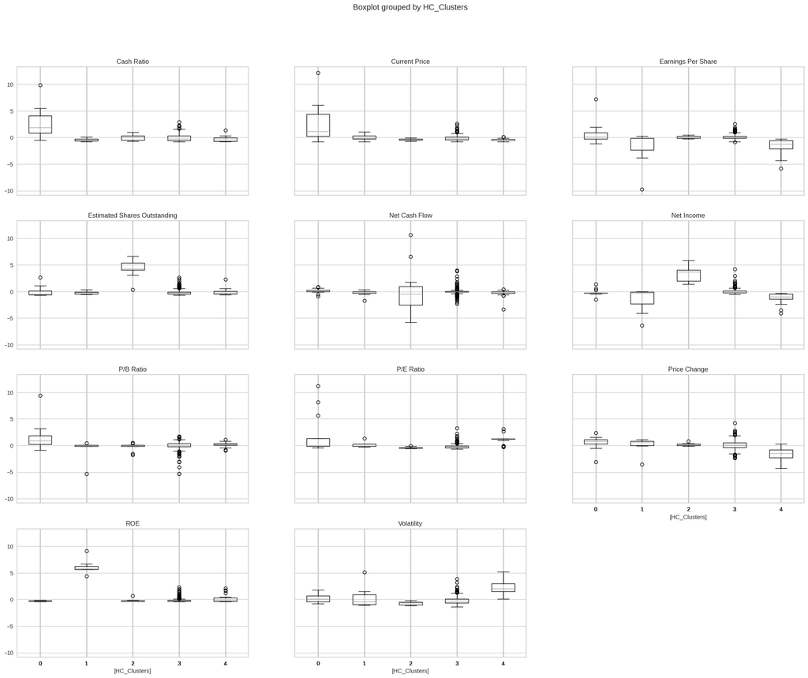

```python
#Create boxplots of different variables and clusters
df_Scaled2.boxplot(by="HC_Clusters", layout = (4,3),figsize=(25,20))
```

```python
# importing library
from sklearn.decomposition import PCA

# setting the number of components to 2
pca = PCA(n_components=2)

# transforming data and storing results in a dataframe
X_reduced_pca = pca.fit_transform(df_Scaled2)
reduced_df_pca = pd.DataFrame(
    data=X_reduced_pca, columns=["Component 1", "Component 2"]
)
```

```python
#Check PCA data variance ratio
pca.explained_variance_ratio_.sum()
```

```
np.float64(0.3717191996354098)
```

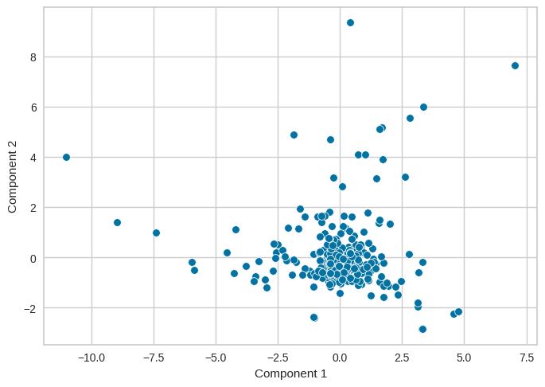

```python
#Plot 2-D PCA scatterplot
sns.scatterplot(data=reduced_df_pca, x="Component 1", y="Component 2")
```

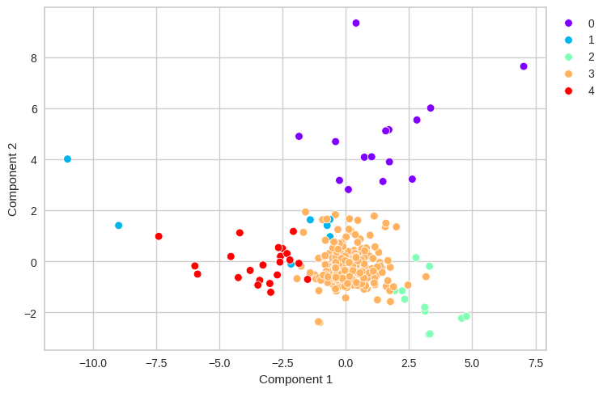

```python
#Plot clusters on 2-D PCA scatter plot
sns.scatterplot(
    data=reduced_df_pca,
    x="Component 1",
    y="Component 2",
    hue=df_2["HC_Clusters"],
    palette="rainbow",
)
plt.legend(bbox_to_anchor=(1, 1))
```

```python
# lets display cluster profile
cluster_profile.style.highlight_max(color="lightgreen", axis=0)
```

| HC_Clusters | Current Price | Price Change | Volatility | ROE | Cash Ratio | Net Cash Flow | Net Income | Earnings Per Share | Estimated Shares Outstanding | P/E Ratio | P/B Ratio | count_in_each_segments |
| --- | --- | --- | --- | --- | --- | --- | --- | --- | --- | --- | --- | --- |
| 0 | 326.198218 | 10.563242 | 1.642560 | 14.400000 | 309.466667 | 288850666.666667 | 864498533.333333 | 7.785333 | 544900261.301333 | 113.095334 | 19.142151 | 15 |
| 1 | 84.355716 | 3.854981 | 1.827670 | 633.571429 | 33.571429 | -568400000.000000 | -4968157142.857142 | -10.841429 | 398169036.442857 | 42.284541 | -11.589502 | 7 |
| 2 | 42.848182 | 6.270446 | 1.123547 | 22.727273 | 71.454545 | 558636363.636364 | 14631272727.272728 | 3.410000 | 4242572567.290909 | 15.242169 | -4.924615 | 11 |
| 3 | 72.760400 | 5.213307 | 1.427078 | 25.603509 | 60.392982 | 79951512.280702 | 1538594322.807018 | 3.655351 | 446472132.228456 | 24.722670 | -2.647194 | 285 |
| 4 | 36.440455 | -16.073408 | 2.832884 | 57.500000 | 42.409091 | -472834090.909091 | -3161045227.272727 | -8.005000 | 514367806.201818 | 85.555682 | 0.836839 | 22 |

```python
# lets display cluster profile
cluster_profile.style.highlight_min(color="lightblue", axis=0)
```

| HC_Clusters | Current Price | Price Change | Volatility | ROE | Cash Ratio | Net Cash Flow | Net Income | Earnings Per Share | Estimated Shares Outstanding | P/E Ratio | P/B Ratio | count_in_each_segments |
| --- | --- | --- | --- | --- | --- | --- | --- | --- | --- | --- | --- | --- |
| 0 | 326.198218 | 10.563242 | 1.642560 | 14.400000 | 309.466667 | 288850666.666667 | 864498533.333333 | 7.785333 | 544900261.301333 | 113.095334 | 19.142151 | 15 |
| 1 | 84.355716 | 3.854981 | 1.827670 | 633.571429 | 33.571429 | -568400000.000000 | -4968157142.857142 | -10.841429 | 398169036.442857 | 42.284541 | -11.589502 | 7 |
| 2 | 42.848182 | 6.270446 | 1.123547 | 22.727273 | 71.454545 | 558636363.636364 | 14631272727.272728 | 3.410000 | 4242572567.290909 | 15.242169 | -4.924615 | 11 |
| 3 | 72.760400 | 5.213307 | 1.427078 | 25.603509 | 60.392982 | 79951512.280702 | 1538594322.807018 | 3.655351 | 446472132.228456 | 24.722670 | -2.647194 | 285 |
| 4 | 36.440455 | -16.073408 | 2.832884 | 57.500000 | 42.409091 | -472834090.909091 | -3161045227.272727 | -8.005000 | 514367806.201818 | 85.555682 | 0.836839 | 22 |

For this hierarchical model using euclidean distance and ward linkage, the clusters can be classified as very low, low, medium, high, and very high risk investments based on their vaolatility score.

Cluster 2 can be classified as "very low" risk with it having the lowest volatility. The companies in this cluster also have the highest cash flow and net income indicating the comapnies good financial health. The earnings per share are modest but for a longterm investment could increase the growth of an investors stock portfolio.

Cluster 3 can be classified as "low" risk with the second lowest volatility score. Cluster three has the largest pool of companies to choose from but with a highercurrent price compared to the cluster 2 companies. The financial health of these companies is also good with a positive net cash flow and net income. earnings per share is slightly higher than cluster 2 but very close. Again long term these companies would provide good growth for an investors stock portfolio, albeit at a slightly higher cost of entry.

Cluster 0 can be classified as "medium" risk based on the volatility score. Earning per share here are the highest but cost of entry is quite high with an average price of $326. The P/E and P/B scores are highest of all clusters also indicating either the companies are expected to grow or the are potentially overvalued. Still a good stock to invest in long term but with larger risk in higher initial cost of the share and no gaurantee the stock will provide more growth in your portfolio than buying more cheaper shares in the "very low" or "low risk" cluster companies.

Cluster 1 can be classified as "high" risk based on its volatility score. The cost of the stock is high at $84 dollars per share and company financial health can be concerning with this cluster having the most negative value cash flow, net income, and earnings per share. ROE is maximum though with 633. P/E ratio is farily high but P/B is negative. These metrics indicate that some of these companies stock could sky rocket but would need to be watched closely to buy and sell at the right times. Would best to have these as short term stocks for investors with high risk tolerence.

Cluster 4 can be classified as "very high" risk based on its highest volatility score of all the clusters. It has the lowest cost crrent price but with the largest negative price change. The clusters financial health is questionable with a negative cash flow and net income. ROE is also relatively low compared to the high risk stock. These stocks would be a massive gamble to invest in even short term and are probably best to be avoided even for the investor with a very high risk tolerence.

### Average (Best Cophenetic Score)

```python
#Create new dataframe copy without GROUP
df_Scaled3 = df_Scaled.drop(['GROUP'], axis=1)
df_Scaled3.head()
```

|  | Current Price | Price Change | Volatility | ROE | Cash Ratio | Net Cash Flow | Net Income | Earnings Per Share | Estimated Shares Outstanding | P/E Ratio | P/B Ratio |
| --- | --- | --- | --- | --- | --- | --- | --- | --- | --- | --- | --- |
| 0 | -0.393341 | 0.493950 | 0.272749 | 0.989601 | -0.210698 | -0.339355 | 1.554415 | 1.309399 | 0.107863 | -0.652487 | -0.506653 |
| 1 | -0.220837 | 0.355439 | 1.137045 | 0.937737 | 0.077269 | -0.002335 | 0.927628 | 0.056755 | 1.250274 | -0.311769 | -0.504205 |
| 2 | -0.367195 | 0.602479 | -0.427007 | -0.192905 | -0.033488 | 0.454058 | 0.744371 | 0.024831 | 1.098021 | -0.391502 | 0.094941 |
| 3 | 0.133567 | 0.825696 | -0.284802 | -0.317379 | 1.218059 | -0.152497 | -0.219816 | -0.230563 | -0.091622 | 0.947148 | 0.424333 |
| 4 | -0.260874 | -0.492636 | 0.296470 | -0.265515 | 2.237018 | 0.133564 | -0.202703 | -0.374982 | 1.978399 | 3.293307 | 0.199196 |

```python
#Create new dataframe copy without GROUP
df_3 = df.drop('GROUP', axis=1)
df_3.head()
```

|  | Ticker Symbol | Security | GICS Sector | GICS Sub Industry | Current Price | Price Change | Volatility | ROE | Cash Ratio | Net Cash Flow | Net Income | Earnings Per Share | Estimated Shares Outstanding | P/E Ratio | P/B Ratio |
| --- | --- | --- | --- | --- | --- | --- | --- | --- | --- | --- | --- | --- | --- | --- | --- |
| 0 | AAL | American Airlines Group | Industrials | Airlines | 42.349998 | 9.999995 | 1.687151 | 135 | 51 | -604000000 | 7610000000 | 11.39 | 6.681299e+08 | 3.718174 | -8.784219 |
| 1 | ABBV | AbbVie | Health Care | Pharmaceuticals | 59.240002 | 8.339433 | 2.197887 | 130 | 77 | 51000000 | 5144000000 | 3.15 | 1.633016e+09 | 18.806350 | -8.750068 |
| 2 | ABT | Abbott Laboratories | Health Care | Health Care Equipment | 44.910000 | 11.301121 | 1.273646 | 21 | 67 | 938000000 | 4423000000 | 2.94 | 1.504422e+09 | 15.275510 | -0.394171 |
| 3 | ADBE | Adobe Systems Inc | Information Technology | Application Software | 93.940002 | 13.977195 | 1.357679 | 9 | 180 | -240840000 | 629551000 | 1.26 | 4.996437e+08 | 74.555557 | 4.199651 |
| 4 | ADI | Analog Devices, Inc. | Information Technology | Semiconductors | 55.320000 | -1.827858 | 1.701169 | 14 | 272 | 315120000 | 696878000 | 0.31 | 2.247994e+09 | 178.451613 | 1.059810 |

```python
#Create model with euclidean distance and average linkage
HCmodel = AgglomerativeClustering(n_clusters=8, metric="euclidean", linkage="average")
HCmodel.fit(df_Scaled3)
```

```
AgglomerativeClustering(linkage='average', n_clusters=8)
```

```python
#Drop GROUP variable
df_3 = df.drop('GROUP', axis=1)
df_3.head()
```

|  | Ticker Symbol | Security | GICS Sector | GICS Sub Industry | Current Price | Price Change | Volatility | ROE | Cash Ratio | Net Cash Flow | Net Income | Earnings Per Share | Estimated Shares Outstanding | P/E Ratio | P/B Ratio |
| --- | --- | --- | --- | --- | --- | --- | --- | --- | --- | --- | --- | --- | --- | --- | --- |
| 0 | AAL | American Airlines Group | Industrials | Airlines | 42.349998 | 9.999995 | 1.687151 | 135 | 51 | -604000000 | 7610000000 | 11.39 | 6.681299e+08 | 3.718174 | -8.784219 |
| 1 | ABBV | AbbVie | Health Care | Pharmaceuticals | 59.240002 | 8.339433 | 2.197887 | 130 | 77 | 51000000 | 5144000000 | 3.15 | 1.633016e+09 | 18.806350 | -8.750068 |
| 2 | ABT | Abbott Laboratories | Health Care | Health Care Equipment | 44.910000 | 11.301121 | 1.273646 | 21 | 67 | 938000000 | 4423000000 | 2.94 | 1.504422e+09 | 15.275510 | -0.394171 |
| 3 | ADBE | Adobe Systems Inc | Information Technology | Application Software | 93.940002 | 13.977195 | 1.357679 | 9 | 180 | -240840000 | 629551000 | 1.26 | 4.996437e+08 | 74.555557 | 4.199651 |
| 4 | ADI | Analog Devices, Inc. | Information Technology | Semiconductors | 55.320000 | -1.827858 | 1.701169 | 14 | 272 | 315120000 | 696878000 | 0.31 | 2.247994e+09 | 178.451613 | 1.059810 |

```python
#Add HC clusters variable to scaled data frame
df_Scaled3["HC_Clusters"] = HCmodel.labels_
df_3["HC_Clusters"] = HCmodel.labels_
```

```python
#Calculate mean values for cluster profiles
cluster_profile = df_3.groupby("HC_Clusters").mean(numeric_only=True)
```

```python
#Group data by clusters and GICS sector
cluster_profile["count_in_each_segments"] = (
    df_3.groupby("HC_Clusters")["GICS Sector"].count().values
)
```

```python
# let's see the names of the companies in each cluster
for cl in df_3["HC_Clusters"].unique():
    print("In cluster {}, the following companies are present:".format(cl))
    print(df_3[df_3["HC_Clusters"] == cl]["Security"].unique())
    print()
```

```
In cluster 2, the following companies are present:
['American Airlines Group' 'AbbVie' 'Abbott Laboratories'
 'Adobe Systems Inc' 'Analog Devices, Inc.' 'Archer-Daniels-Midland Co'
 'Ameren Corp' 'American Electric Power' 'AFLAC Inc'
 'American International Group, Inc.' 'Apartment Investment & Mgmt'
 'Assurant Inc' 'Arthur J. Gallagher & Co.' 'Akamai Technologies Inc'
 'Albemarle Corp' 'Alaska Air Group Inc' 'Allstate Corp' 'Allegion'
 'Applied Materials Inc' 'AMETEK Inc' 'Affiliated Managers Group Inc'
 'Amgen Inc' 'Ameriprise Financial' 'American Tower Corp A'
 'AutoNation Inc' 'Anthem Inc.' 'Aon plc' 'Anadarko Petroleum Corp'
 'Amphenol Corp' 'Arconic Inc' 'Activision Blizzard'
 'AvalonBay Communities, Inc.' 'Broadcom'
 'American Water Works Company Inc' 'American Express Co' 'Boeing Company'
 'Baxter International Inc.' 'BB&T Corporation' 'Bard (C.R.) Inc.'
 'Baker Hughes Inc' 'BIOGEN IDEC Inc.' 'The Bank of New York Mellon Corp.'
 'Ball Corp' 'Bristol-Myers Squibb' 'Boston Scientific' 'BorgWarner'
 'Boston Properties' 'Citigroup Inc.' 'Caterpillar Inc.' 'Chubb Limited'
 'CBRE Group' 'Crown Castle International Corp.' 'Carnival Corp.'
 'Celgene Corp.' 'CF Industries Holdings Inc' 'Citizens Financial Group'
 'Church & Dwight' 'C. H. Robinson Worldwide' 'Charter Communications'
 'CIGNA Corp.' 'Cincinnati Financial' 'Colgate-Palmolive' 'Comerica Inc.'
 'CME Group Inc.' 'Chipotle Mexican Grill' 'Cummins Inc.' 'CMS Energy'
 'Centene Corporation' 'CenterPoint Energy' 'Capital One Financial'
 'Cabot Oil & Gas' 'The Cooper Companies' 'CSX Corp.' 'CenturyLink Inc'
 'Cognizant Technology Solutions' 'Citrix Systems' 'CVS Health'
 'Chevron Corp.' 'Concho Resources' 'Dominion Resources' 'Delta Air Lines'
 'Du Pont (E.I.)' 'Deere & Co.' 'Discover Financial Services'
 'Quest Diagnostics' 'Danaher Corp.' 'The Walt Disney Company'
 'Discovery Communications-A' 'Discovery Communications-C'
 'Delphi Automotive' 'Digital Realty Trust' 'Dun & Bradstreet'
 'Dover Corp.' 'Dr Pepper Snapple Group' 'Duke Energy' 'DaVita Inc.'
 'Devon Energy Corp.' 'eBay Inc.' 'Ecolab Inc.' 'Consolidated Edison'
 'Equifax Inc.' "Edison Int'l" 'Eastman Chemical' 'EOG Resources'
 'Equinix' 'Equity Residential' 'EQT Corporation' 'Eversource Energy'
 'Essex Property Trust, Inc.' 'E*Trade' 'Eaton Corporation'
 'Entergy Corp.' 'Edwards Lifesciences' 'Exelon Corp.' "Expeditors Int'l"
 'Expedia Inc.' 'Extra Space Storage' 'Ford Motor' 'Fastenal Co'
 'Fortune Brands Home & Security' 'Freeport-McMoran Cp & Gld'
 'FirstEnergy Corp' 'Fidelity National Information Services' 'Fiserv Inc'
 'FLIR Systems' 'Fluor Corp.' 'Flowserve Corporation' 'FMC Corporation'
```

[output cut: 71 more lines]

```

In cluster 7, the following companies are present:
['Apache Corporation']

In cluster 1, the following companies are present:
['Bank of America Corp' 'Intel Corp.']

In cluster 6, the following companies are present:
['Chesapeake Energy']

In cluster 3, the following companies are present:
['Facebook']

In cluster 4, the following companies are present:
['Priceline.com Inc']
```

```python
# lets display cluster profile
cluster_profile.style.highlight_max(color="lightgreen", axis=0)
```

| HC_Clusters | Current Price | Price Change | Volatility | ROE | Cash Ratio | Net Cash Flow | Net Income | Earnings Per Share | Estimated Shares Outstanding | P/E Ratio | P/B Ratio | count_in_each_segments |
| --- | --- | --- | --- | --- | --- | --- | --- | --- | --- | --- | --- | --- |
| 0 | 327.006671 | 21.917380 | 2.029752 | 4.000000 | 106.000000 | 698240666.666667 | 287547000.000000 | 0.750000 | 366763235.300000 | 400.989188 | -5.322376 | 3 |
| 1 | 25.640000 | 11.237908 | 1.322355 | 12.500000 | 130.500000 | 16755500000.000000 | 13654000000.000000 | 3.295000 | 2791829362.100000 | 13.649696 | 1.508484 | 2 |
| 2 | 75.017416 | 3.937751 | 1.513415 | 35.621212 | 66.545455 | -39846757.575758 | 1549443100.000000 | 2.904682 | 562266326.402576 | 29.091275 | -2.146308 | 330 |
| 3 | 104.660004 | 16.224320 | 1.320606 | 8.000000 | 958.000000 | 592000000.000000 | 3669000000.000000 | 1.310000 | 2800763359.000000 | 79.893133 | 5.884467 | 1 |
| 4 | 1274.949951 | 3.190527 | 1.268340 | 29.000000 | 184.000000 | -1671386000.000000 | 2551360000.000000 | 50.090000 | 50935516.070000 | 25.453183 | -1.052429 | 1 |
| 5 | 276.570007 | 6.189286 | 1.116976 | 30.000000 | 25.000000 | 90885000.000000 | 596541000.000000 | 8.910000 | 66951851.850000 | 31.040405 | 129.064585 | 1 |
| 6 | 4.500000 | -38.101788 | 4.559815 | 687.000000 | 22.000000 | -3283000000.000000 | -14685000000.000000 | -22.430000 | 654703522.100000 | 28.407929 | -1.840528 | 1 |
| 7 | 44.470001 | 11.397804 | 2.405408 | 917.000000 | 80.000000 | 698000000.000000 | -23528000000.000000 | -61.200000 | 384444444.400000 | 93.089287 | 4.970809 | 1 |

```python
# lets display cluster profile
cluster_profile.style.highlight_min(color="lightblue", axis=0)
```

| HC_Clusters | Current Price | Price Change | Volatility | ROE | Cash Ratio | Net Cash Flow | Net Income | Earnings Per Share | Estimated Shares Outstanding | P/E Ratio | P/B Ratio | count_in_each_segments |
| --- | --- | --- | --- | --- | --- | --- | --- | --- | --- | --- | --- | --- |
| 0 | 327.006671 | 21.917380 | 2.029752 | 4.000000 | 106.000000 | 698240666.666667 | 287547000.000000 | 0.750000 | 366763235.300000 | 400.989188 | -5.322376 | 3 |
| 1 | 25.640000 | 11.237908 | 1.322355 | 12.500000 | 130.500000 | 16755500000.000000 | 13654000000.000000 | 3.295000 | 2791829362.100000 | 13.649696 | 1.508484 | 2 |
| 2 | 75.017416 | 3.937751 | 1.513415 | 35.621212 | 66.545455 | -39846757.575758 | 1549443100.000000 | 2.904682 | 562266326.402576 | 29.091275 | -2.146308 | 330 |
| 3 | 104.660004 | 16.224320 | 1.320606 | 8.000000 | 958.000000 | 592000000.000000 | 3669000000.000000 | 1.310000 | 2800763359.000000 | 79.893133 | 5.884467 | 1 |
| 4 | 1274.949951 | 3.190527 | 1.268340 | 29.000000 | 184.000000 | -1671386000.000000 | 2551360000.000000 | 50.090000 | 50935516.070000 | 25.453183 | -1.052429 | 1 |
| 5 | 276.570007 | 6.189286 | 1.116976 | 30.000000 | 25.000000 | 90885000.000000 | 596541000.000000 | 8.910000 | 66951851.850000 | 31.040405 | 129.064585 | 1 |
| 6 | 4.500000 | -38.101788 | 4.559815 | 687.000000 | 22.000000 | -3283000000.000000 | -14685000000.000000 | -22.430000 | 654703522.100000 | 28.407929 | -1.840528 | 1 |
| 7 | 44.470001 | 11.397804 | 2.405408 | 917.000000 | 80.000000 | 698000000.000000 | -23528000000.000000 | -61.200000 | 384444444.400000 | 93.089287 | 4.970809 | 1 |

```
array([[<Axes: title={'center': 'Cash Ratio'}, xlabel='[HC_Clusters]'>,
        <Axes: title={'center': 'Current Price'}, xlabel='[HC_Clusters]'>,
        <Axes: title={'center': 'Earnings Per Share'}, xlabel='[HC_Clusters]'>],
       [<Axes: title={'center': 'Estimated Shares Outstanding'}, xlabel='[HC_Clusters]'>,
        <Axes: title={'center': 'Net Cash Flow'}, xlabel='[HC_Clusters]'>,
        <Axes: title={'center': 'Net Income'}, xlabel='[HC_Clusters]'>],
       [<Axes: title={'center': 'P/B Ratio'}, xlabel='[HC_Clusters]'>,
        <Axes: title={'center': 'P/E Ratio'}, xlabel='[HC_Clusters]'>,
        <Axes: title={'center': 'Price Change'}, xlabel='[HC_Clusters]'>],
       [<Axes: title={'center': 'ROE'}, xlabel='[HC_Clusters]'>,
        <Axes: title={'center': 'Volatility'}, xlabel='[HC_Clusters]'>,
        <Axes: >]], dtype=object)
```

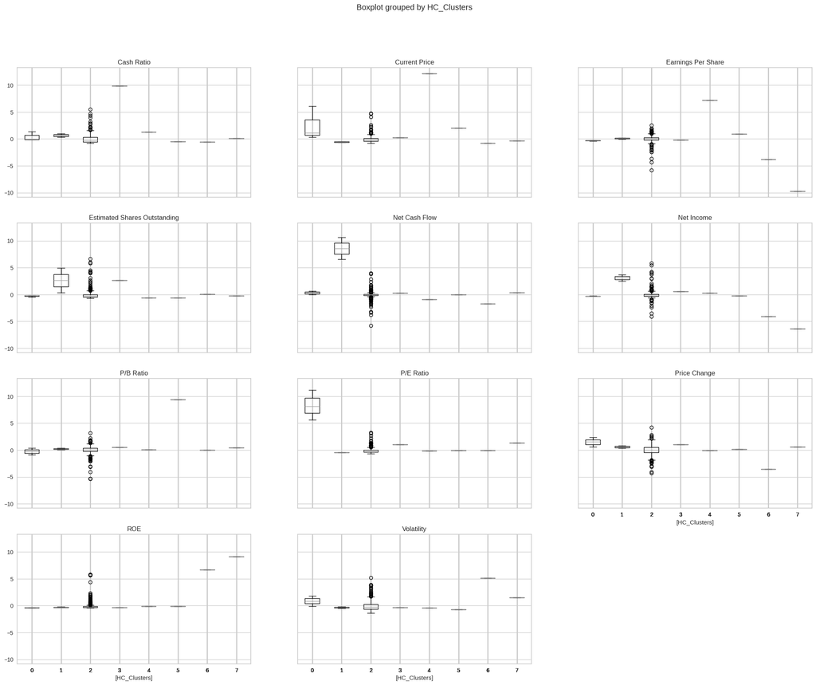

```python
#Plot scatter plot of all variables and clusters
df_Scaled3.boxplot(by="HC_Clusters", layout = (4,3),figsize=(25,20))
```

```python
# importing library
from sklearn.decomposition import PCA

# setting the number of components to 2
pca = PCA(n_components=2)

# transforming data and storing results in a dataframe
X_reduced_pca = pca.fit_transform(df_Scaled3)
reduced_df_pca = pd.DataFrame(
    data=X_reduced_pca, columns=["Component 1", "Component 2"]
)
```

```python
#Check pca variance ratio
pca.explained_variance_ratio_.sum()
```

```
np.float64(0.3665519204957951)
```

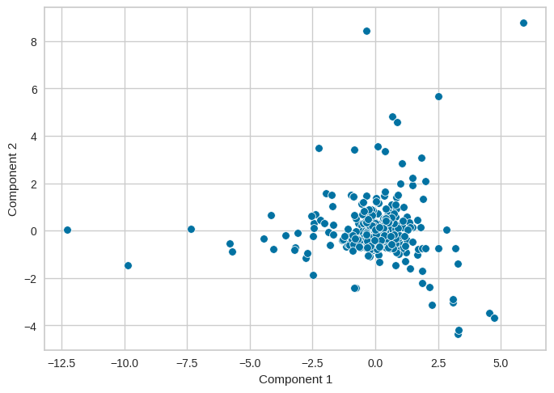

```python
#Plot 2-D PCA scatterplot
sns.scatterplot(data=reduced_df_pca, x="Component 1", y="Component 2")
```

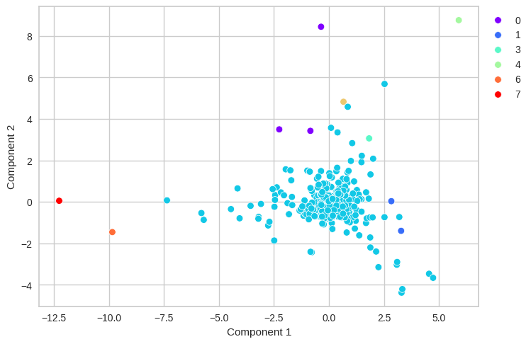

```python
#Plot clusters on 2-D scatter plot
sns.scatterplot(
    data=reduced_df_pca,
    x="Component 1",
    y="Component 2",
    hue=df_3["HC_Clusters"],
    palette="rainbow",
)
plt.legend(bbox_to_anchor=(1, 1))
```

Though the cophenetic score is high for euclidean distance and average linkage, even with 8 clusters, most clusters only have 1 - 3 companies except for the largest cluster.

In this context, this clustering does not provide any value as it indicates that almost all companies except for a handful should be treated as good investments. This most likely generalizes too much for these companies and could hurt a potential investors portfolio.

## K-means vs Hierarchical Clustering

You compare several things, like:

- Which clustering technique took less time for execution?

Though both K-Means and Hierarchical clustering methods were fast, K-Means was the fastest to create and test.

- Which clustering technique gave you more distinct clusters, or are they the same?

K-Means of k=4 and the euclidean distance ward linkage hierarchical clustering with k=5 provided the most distinct cluster. Very similar in terms of grouping and providing roughly the same cluster classification groups for Trade&Ahead to consider when consulting its customers.

- How many observations are there in the similar clusters of both algorithms?

For the K-Means clusters:

k=4

C0 - 295

C1 - 32

C2 - 2

C3 - 11

For Hierarchical Clustering:

C0 - 15

C1 - 7

C2 - 11

C3 - 285

C4 - 22

- How many clusters are obtained as the appropriate number of clusters from both algorithms?

As stated above K-Means had good results with 3 and 4 clusters and Hierarchical Clustering a good reuslt with 5.

You can also mention any differences or similarities you obtained in the cluster profiles from both the clustering techniques.

The K- Means and euclidean ward hierarchical clustering methods yielded similar results though looking at the PCA scatter plot cluster visualization the K-Means seems to provide slightly better distinguished clusters. Though both are close in terms of the overall clustering.

Looking at the boxplots of the K-Means vvs hierarchical clustering, the K-Means provides better variance of different metric between groups. This I think provdes better insights into which stocks are least and most risky for investors to invest in. The hierarchical clustering booxplots for the most part are more uniform and less varied.

## Actionable Insights and Recommendations

- Stocks in this data can generally be characterized as very low, low, medium, and high risk stocks.
- There are only 2 high risk companies 'Apache Corporation', and 'Chesapeake Energy'. These companies can be invested in but would be for the customers with highest risk tolerence and would only want the stocks for short term.
- The low risk and very low risk companies have the largest company pool and provide a safe pool of companies to invest in long term. Portfoliio returns will come slower but over many years will provide a safe return on investment. These investments would also be good for older investors with no income who are generally less risk averse.
- Medium risk companies would be good for younger investors who plan to do long term investing but have time to recoup losses from more risky investments. Overtime, these medium risk investments could provide much larger returns vs only investing in the lower risk companies.
- Generally speaking, energy companies tend to be more risky investments compared to other industries. These could be good investments for hgih risk tolerence clients.